# COVID-19 Global Data Tracker

Welcome to your COVID-19 data analysis project. In this notebook, we’ll analyze trends in global COVID-19 data including cases, deaths, and vaccinations.

```python
# Step 1: Import Libraries
import pandas as pd
import numpy as np
import matplotlib.pyplot as plt
import seaborn as sns
import plotly.express as px

# Configure plots
sns.set(style='whitegrid')
plt.rcParams['figure.figsize'] = (14, 7)
```

```python
# Step 2: Load the COVID-19 dataset
df = pd.read_csv("owid-covid-data/owid-covid-data.csv")
df.head()
```

|  | iso_code | continent | location | date | total_cases | new_cases | new_cases_smoothed | total_deaths | new_deaths | new_deaths_smoothed | ... | male_smokers | handwashing_facilities | hospital_beds_per_thousand | life_expectancy | human_development_index | population | excess_mortality_cumulative_absolute | excess_mortality_cumulative | excess_mortality | excess_mortality_cumulative_per_million |
| --- | --- | --- | --- | --- | --- | --- | --- | --- | --- | --- | --- | --- | --- | --- | --- | --- | --- | --- | --- | --- | --- |
| 0 | AFG | Asia | Afghanistan | 2020-01-03 | NaN | 0.0 | NaN | NaN | 0.0 | NaN | ... | NaN | 37.746 | 0.5 | 64.83 | 0.511 | 41128772.0 | NaN | NaN | NaN | NaN |
| 1 | AFG | Asia | Afghanistan | 2020-01-04 | NaN | 0.0 | NaN | NaN | 0.0 | NaN | ... | NaN | 37.746 | 0.5 | 64.83 | 0.511 | 41128772.0 | NaN | NaN | NaN | NaN |
| 2 | AFG | Asia | Afghanistan | 2020-01-05 | NaN | 0.0 | NaN | NaN | 0.0 | NaN | ... | NaN | 37.746 | 0.5 | 64.83 | 0.511 | 41128772.0 | NaN | NaN | NaN | NaN |
| 3 | AFG | Asia | Afghanistan | 2020-01-06 | NaN | 0.0 | NaN | NaN | 0.0 | NaN | ... | NaN | 37.746 | 0.5 | 64.83 | 0.511 | 41128772.0 | NaN | NaN | NaN | NaN |
| 4 | AFG | Asia | Afghanistan | 2020-01-07 | NaN | 0.0 | NaN | NaN | 0.0 | NaN | ... | NaN | 37.746 | 0.5 | 64.83 | 0.511 | 41128772.0 | NaN | NaN | NaN | NaN |

5 rows × 67 columns

```python
# 🔍 Step 3: Explore the dataset
print("\nColumns in the dataset:")
print(df.columns.tolist())

print("\nMissing values per column:")
print(df.isnull().sum())
```

```
Columns in the dataset:
['iso_code', 'continent', 'location', 'date', 'total_cases', 'new_cases', 'new_cases_smoothed', 'total_deaths', 'new_deaths', 'new_deaths_smoothed', 'total_cases_per_million', 'new_cases_per_million', 'new_cases_smoothed_per_million', 'total_deaths_per_million', 'new_deaths_per_million', 'new_deaths…

Missing values per column:
iso_code                                        0
continent                                   14352
location                                        0
date                                            0
total_cases                                 35741
                                            ...
population                                      0
excess_mortality_cumulative_absolute       292217
excess_mortality_cumulative                292217
excess_mortality                           292217
excess_mortality_cumulative_per_million    292217
Length: 67, dtype: int64
```

```python
# Step 4: Data Cleaning - Filter and Prepare

# Filter the data for Kenya, Rwanda, and USA
countries = ['Kenya', 'Rwanda', 'United States']
df_filtered = df[df['location'].isin(countries)].copy()

# Convert date column to datetime
df_filtered['date'] = pd.to_datetime(df_filtered['date'])

# Sort by location and date
df_filtered = df_filtered.sort_values(by=['location', 'date'])

# Interpolate missing values for key numeric columns
cols_to_interp = ['total_cases', 'total_deaths', 'total_vaccinations']
df_filtered[cols_to_interp] = df_filtered[cols_to_interp].interpolate(method='linear')

# Preview cleaned data
df_filtered.head()
```

|  | iso_code | continent | location | date | total_cases | new_cases | new_cases_smoothed | total_deaths | new_deaths | new_deaths_smoothed | ... | male_smokers | handwashing_facilities | hospital_beds_per_thousand | life_expectancy | human_development_index | population | excess_mortality_cumulative_absolute | excess_mortality_cumulative | excess_mortality | excess_mortality_cumulative_per_million |
| --- | --- | --- | --- | --- | --- | --- | --- | --- | --- | --- | --- | --- | --- | --- | --- | --- | --- | --- | --- | --- | --- |
| 136231 | KEN | Africa | Kenya | 2020-01-03 | NaN | 0.0 | NaN | NaN | 0.0 | NaN | ... | 20.4 | 24.651 | 1.4 | 66.7 | 0.601 | 54027484.0 | NaN | NaN | NaN | NaN |
| 136232 | KEN | Africa | Kenya | 2020-01-04 | NaN | 0.0 | NaN | NaN | 0.0 | NaN | ... | 20.4 | 24.651 | 1.4 | 66.7 | 0.601 | 54027484.0 | NaN | NaN | NaN | NaN |
| 136233 | KEN | Africa | Kenya | 2020-01-05 | NaN | 0.0 | NaN | NaN | 0.0 | NaN | ... | 20.4 | 24.651 | 1.4 | 66.7 | 0.601 | 54027484.0 | NaN | NaN | NaN | NaN |
| 136234 | KEN | Africa | Kenya | 2020-01-06 | NaN | 0.0 | NaN | NaN | 0.0 | NaN | ... | 20.4 | 24.651 | 1.4 | 66.7 | 0.601 | 54027484.0 | NaN | NaN | NaN | NaN |
| 136235 | KEN | Africa | Kenya | 2020-01-07 | NaN | 0.0 | NaN | NaN | 0.0 | NaN | ... | 20.4 | 24.651 | 1.4 | 66.7 | 0.601 | 54027484.0 | NaN | NaN | NaN | NaN |

5 rows × 67 columns

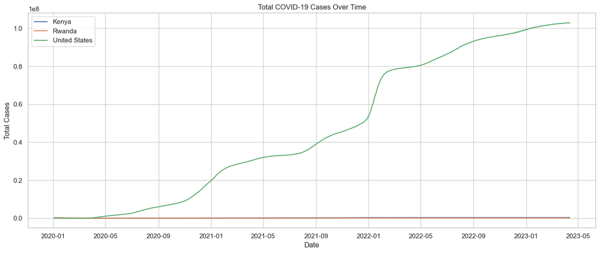

```python
# Total cases over time
plt.figure(figsize=(14, 6))
for country in countries:
    data = df_filtered[df_filtered['location'] == country]
    plt.plot(data['date'], data['total_cases'], label=country)
plt.title('Total COVID-19 Cases Over Time')
plt.xlabel('Date')
plt.ylabel('Total Cases')
plt.legend()
plt.tight_layout()
plt.show()
```

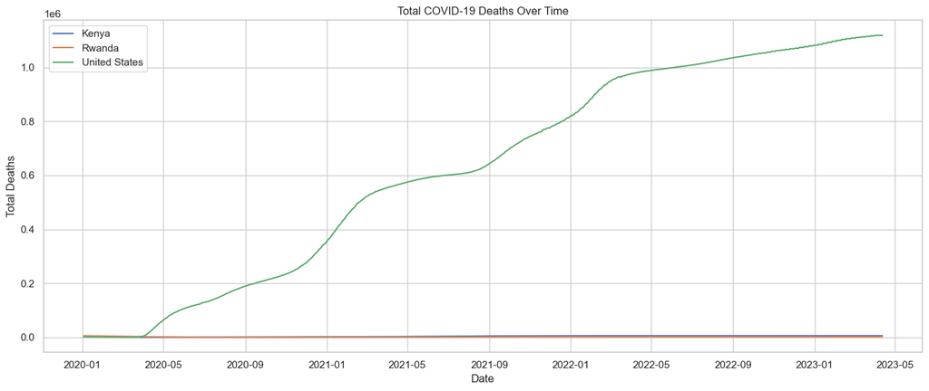

```python
# Total deaths over time
plt.figure(figsize=(14, 6))
for country in countries:
    data = df_filtered[df_filtered['location'] == country]
    plt.plot(data['date'], data['total_deaths'], label=country)
plt.title('Total COVID-19 Deaths Over Time')
plt.xlabel('Date')
plt.ylabel('Total Deaths')
plt.legend()
plt.tight_layout()
plt.show()
```

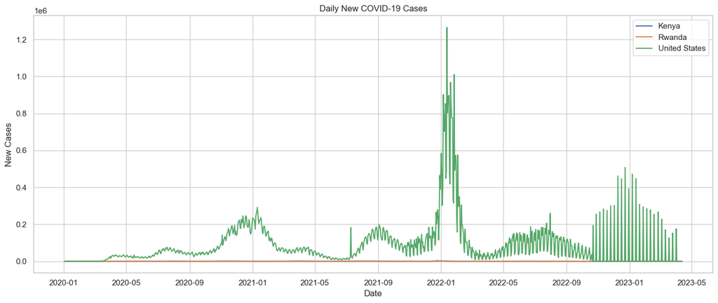

```python
# Daily new cases comparison
plt.figure(figsize=(14, 6))
for country in countries:
    data = df_filtered[df_filtered['location'] == country]
    plt.plot(data['date'], data['new_cases'], label=country)
plt.title('Daily New COVID-19 Cases')
plt.xlabel('Date')
plt.ylabel('New Cases')
plt.legend()
plt.tight_layout()
plt.show()
```

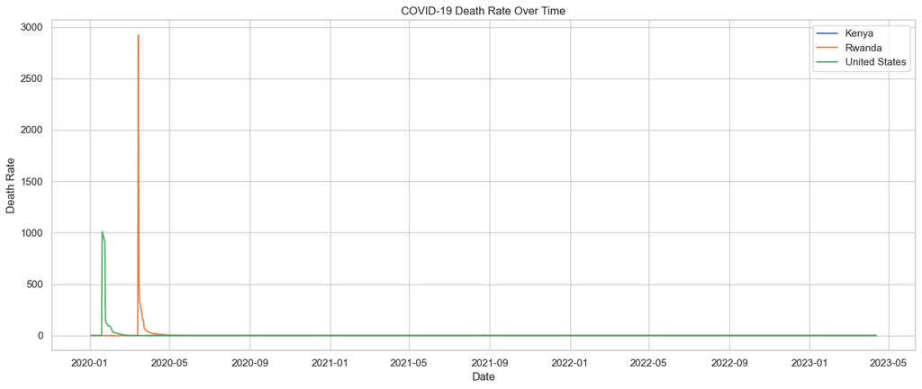

```python
# Death rate: total_deaths / total_cases
df_filtered['death_rate'] = df_filtered['total_deaths'] / df_filtered['total_cases']

plt.figure(figsize=(14, 6))
for country in countries:
    data = df_filtered[df_filtered['location'] == country]
    plt.plot(data['date'], data['death_rate'], label=country)
plt.title('COVID-19 Death Rate Over Time')
plt.xlabel('Date')
plt.ylabel('Death Rate')
plt.legend()
plt.tight_layout()
plt.show()
```

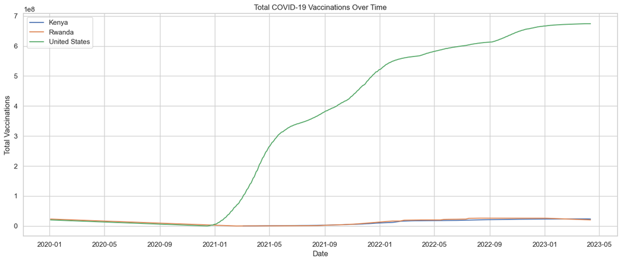

```python
# Total vaccinations over time
plt.figure(figsize=(14, 6))
for country in countries:
    data = df_filtered[df_filtered['location'] == country]
    plt.plot(data['date'], data['total_vaccinations'], label=country)
plt.title('Total COVID-19 Vaccinations Over Time')
plt.xlabel('Date')
plt.ylabel('Total Vaccinations')
plt.legend()
plt.tight_layout()
plt.show()
```

# Choropleth Map – Total Cases by Country (Latest Date)

```python
# 📌 Step 1: Get the latest available date in dataset
latest_date = df['date'].max()

# 📌 Step 2: Filter dataset for latest date
latest_df = df[df['date'] == latest_date]

# 📌 Step 3: Keep only necessary columns and drop NaNs
choropleth_df = latest_df[['iso_code', 'location', 'total_cases']].dropna()

# 📌 Step 4: Plot Choropleth Map
fig = px.choropleth(
    choropleth_df,
    locations='iso_code',
    color='total_cases',
    hover_name='location',
    color_continuous_scale='OrRd',
    title=f'Total COVID-19 Cases by Country on {latest_date}',
    labels={'total_cases': 'Total Cases'}
)
fig.update_layout(geo=dict(showframe=False, showcoastlines=False))
fig.show()
```

[output not shown]

## Insights Summary

### 1. Vaccine Rollout

- The United States shows the fastest and earliest vaccine rollout among the selected countries.
- Kenya and Rwanda started vaccinations later and at a slower pace, though Rwanda shows a consistent upward trend.

### 2. Case Trends

- The U.S. experienced multiple waves with very high daily new cases compared to Kenya and Rwanda.
- Rwanda managed to keep total cases significantly lower despite proximity to global hotspots.

### 4. Anomalies

- Data gaps or unexpected drops in daily cases or vaccinations were seen for Rwanda during certain periods — likely due to reporting delays.
- Some countries report "0" new cases on weekends — indicative of batch reporting.

## Recommendations for Further Analysis

- Explore population-adjusted metrics (cases per million, vaccinations per 100 people).
- Compare testing rates and positivity ratios.
- Include socioeconomic or healthcare infrastructure data to interpret the results better.